# Canine Skin Microbiome: ITS Change-Point Analysis

Spencer Toth

2026-09-20

**Purpose:** Investigate how canine skin microbial composition changes in result of disturbance (surgery).

**Null Hypothesis:** No change-point in bray-curtis dissimilarity between paired control and surgical sites of dogs before surgery.

**Description:** Each dog has its own control prior to surgery as well as a control site that did not undergo surgery. This allowed us to model how within-dog control–surgical dissimilarity changed with number of days since surgery.

**References:**

- Longitudinal profiling of the microbiome at four body sites reveals core stability and individualized dynamics during health and disease (Cell Host Microbe - April 2025) https://pmc.ncbi.nlm.nih.gov/articles/PMC11022754/
- Metagenomic characterisation of canine skin reveals a core healthy skin microbiome (Nature - August 2024) https://www.nature.com/articles/s41598-024-63999-5
- Cutaneous Microbiome Profiles Following Chlorhexidine Treatment in a 72-Hour Daily Follow-Up Paired Design: a Pilot Study (ASM - June 2022) https://journals.asm.org/doi/full/10.1128/spectrum.01753-21

# Load R packages

```r
library(knitr)
library(FSA)
library(tidyverse)
library(vegan)
library(phyloseq)
library(ggplot2)
library(ggtree)
library(scales)
library(RColorBrewer)
library(segmented)
library(stringr)
library(pairwiseAdonis)
library(ggpubr)
library(changepoint)
library(dplyr)
library(lme4)
library(emmeans)
library(nortest)
library(mcp)
library(purrr)
library(kableExtra)
library(forcats)
```

# Generate Paired-Only

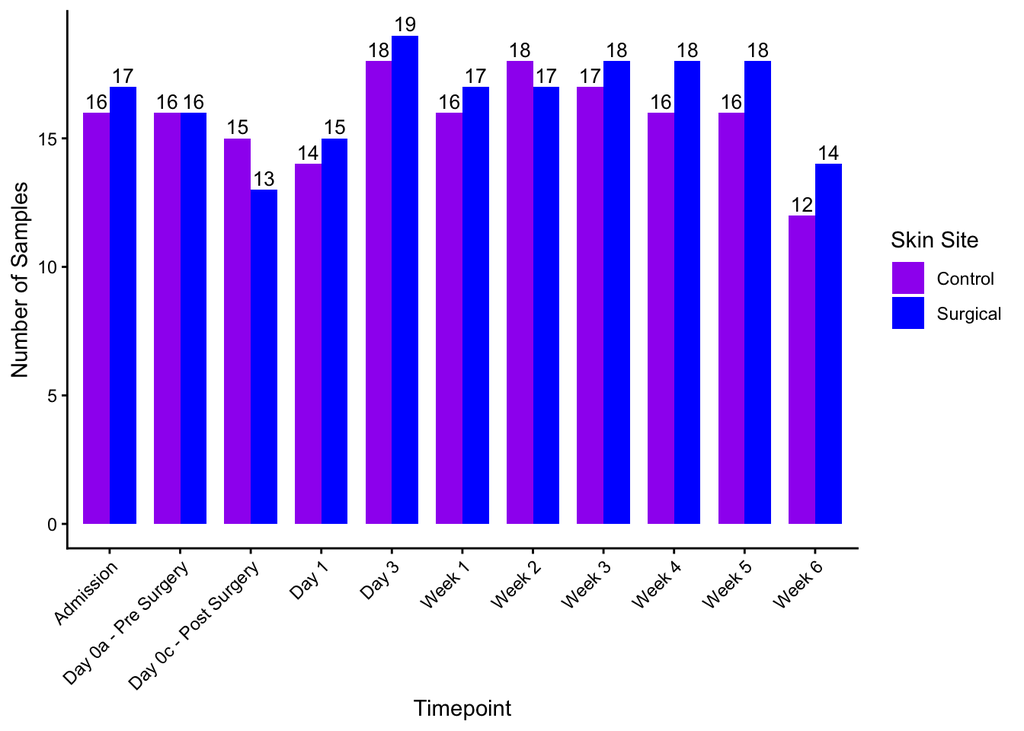

```r
ps_1 <- readRDS("../01_input_files/phyloseq/ps_1.rds")

metadata <- as(sample_data(ps_1), "data.frame")

# Set timepoint order
day_levels <- c(
  "Admission",
  "Day 0a - Pre Surgery",
  "Day 0c - Post Surgery",
  "Day 1",
  "Day 3",
  "Week 1",
  "Week 2",
  "Week 3",
  "Week 4",
  "Week 5",
  "Week 6"
)
metadata$Day_Order <- factor(metadata$Day_Order, levels = day_levels)
metadata$Sample_Site <- factor(metadata$Sample_Site, levels = c("Control", "Surgical"))

#Count skin samples across timepoints
count_df <- metadata %>%
  dplyr::select(Day_Order, Sample_Site, Sample_Unique) %>%
  distinct() %>%
  group_by(Day_Order, Sample_Site) %>%
  summarise(n = n(), .groups = "drop")


count_df$Day_Order <- factor(count_df$Day_Order, levels = day_levels)
count_df$Sample_Site <- factor(count_df$Sample_Site, levels = c("Control", "Surgical"))

p <- ggplot(count_df, aes(x = Day_Order, y = n, fill = Sample_Site)) +
  geom_col(position = position_dodge(width = 0.75), width = 0.75) +
  geom_text(
    aes(label = n),
    position = position_dodge(width = 0.75),
    vjust = -0.3,
    size = 3.5
  ) +
  scale_fill_manual(values = c("Control" = "purple", "Surgical" = "blue")) +
  labs(
    x = "Timepoint",
    y = "Number of Samples",
    fill = "Skin Site"
  ) +
  theme_classic() +
  theme(
    axis.text.x = element_text(angle = 45, hjust = 1),
    legend.position = "right"
  )

print(p)
```

```r
# Check which dogs are missing samples (either control or surgical) at each timepoint
missing_sample_unique <- metadata %>%
  group_by(Individual, Day_Order) %>%
  summarise(
    site_absent = if (all(c("Control", "Surgical") %in% Sample_Site)) NA_character_
                  else paste(setdiff(c("Control", "Surgical"), unique(Sample_Site)), collapse = ", "),
    Sample_Unique = paste(sort(unique(Sample_Unique)), collapse = ", "),
    n_sites = n_distinct(Sample_Site),
    .groups = "drop"
  ) %>%
  filter(n_sites < 2) %>%
  dplyr::select(Individual, Day_Order, site_absent, Sample_Unique) %>%
  arrange(Individual, Day_Order)

print(missing_sample_unique)
```

```
## # A tibble: 34 × 4
##    Individual Day_Order             site_absent Sample_Unique
##    <chr>      <fct>                 <chr>       <chr>
##  1 CH003      Day 0c - Post Surgery Surgical    3PostC
##  2 CH003      Day 1                 Control     3D1S
##  3 CH003      Week 1                Control     3D7S
##  4 CH003      Week 4                Control     3D28S
##  5 CH005      Day 0a - Pre Surgery  Surgical    5PreC
##  6 CH005      Day 1                 Control     5D1S
##  7 CH005      Week 1                Control     5D7S
##  8 CH005      Week 2                Control     5D14S
##  9 CH008      Day 0c - Post Surgery Control     8PostS
## 10 CH009      Week 2                Surgical    9D14C
## # ℹ 24 more rows
```

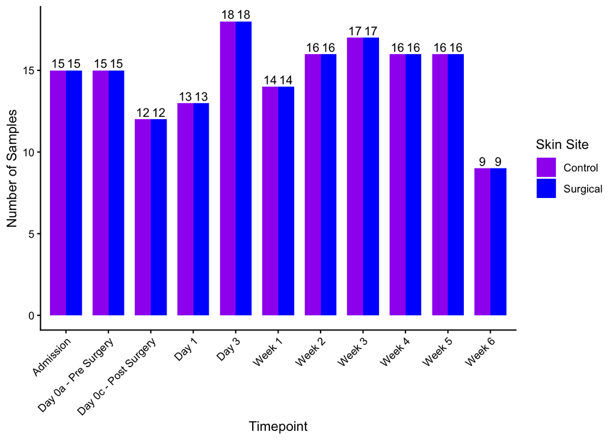

```r
# Keep only samples that have control and surgical at each Day_Order
paired_groups <- metadata %>%
  group_by(Individual, Day_Order) %>%
  summarize(n_sites = n_distinct(Sample_Site), .groups = "drop") %>%
  filter(n_sites == 2) %>%
  transmute(Individual, Day_Order)
paired_sample_data <- metadata %>%
  inner_join(paired_groups, by = c("Individual", "Day_Order"))


# Prune phyloseq object so it only contains these remaining samples
ps_2 <- prune_samples(paired_sample_data$SampleID, ps_1)
out_dir <- "../01_input_files/phyloseq"
dir.create(out_dir, recursive = TRUE, showWarnings = FALSE)
saveRDS(ps_2, file = file.path(out_dir, "ps_2.rds"))

# Normalize read counts by dividing by total read count per sample (relative abundance)
ps_rel_2 <- transform_sample_counts(ps_2, function(x) x / sum(x))

# Count unique samples by Day_Order and Sample_Site
count_df <- paired_sample_data %>%
  dplyr::select(Day_Order, Sample_Site, Sample_Unique) %>%
  distinct() %>%
  group_by(Day_Order, Sample_Site) %>%
  summarise(n = n(), .groups = "drop")


count_df$Day_Order <- factor(count_df$Day_Order, levels = day_levels)


count_df$Sample_Site <- factor(count_df$Sample_Site, levels = c("Control", "Surgical"))

# Updated after removing dog-timepoint samples with only one site
p <- ggplot(count_df, aes(x = Day_Order, y = n, fill = Sample_Site)) +
  geom_col(position = position_dodge(width = 0.75), width = 0.75) +
  geom_text(
    aes(label = n),
    position = position_dodge(width = 0.75),
    vjust = -0.3,
    size = 3.5
  ) +
  scale_fill_manual(values = c("Control" = "purple", "Surgical" = "blue")) +
  labs(
    x = "Timepoint",
    y = "Number of Samples",
    fill = "Skin Site"
  ) +
  theme_classic() +
  theme(
    axis.text.x = element_text(angle = 45, hjust = 1),
    legend.position = "right"
  )

print(p)
```

```r
paired_sample_data$Sample_Site <- factor(paired_sample_data$Sample_Site)
paired_sample_data$Dog_ID <- factor(paired_sample_data$Dog_ID)
paired_sample_data$Sample_Plate <- factor(paired_sample_data$Sample_Plate)
paired_sample_data$Collection_Day <- as.numeric(paired_sample_data$Collection_Day)


dog_library_table <- with(
  paired_sample_data,
  table(Individual, Sample_Plate)
)
dog_library_table <- rbind(
  dog_library_table,
  Total = colSums(dog_library_table)
)
dog_library_table
```

```
##       CHLib1 CHLib2 CHLib3 CHLib4
## CH001     22      0      0      0
## CH003      0     12      0      0
## CH005     14      0      0      0
## CH006     18      0      0      0
## CH008     18      0      0      0
## CH009      0      0     14      0
## CH011      0     14      0      0
## CH012     22      0      0      0
## CH013      0     16      0      0
## CH014      0     18      0      0
## CH016      0     20      0      0
## CH018      0      0      0     18
## CH019      0      0      0     22
## CH020      0      0      6      0
## CH021      0      0      0     20
## CH022      0      0     12      0
## CH023      0      0      0     20
## CH024      0      0     16      0
## CH025      0      0     20      0
## Total     94     80     68     80
```

```r
out_table <- paste0(out_dir, "/total_paired_samples_by_individual.png")

dog_library_table_bold <- dog_library_table
dog_library_table_bold[dog_library_table_bold != 0] <- paste0(
  "<b>", dog_library_table_bold[dog_library_table_bold != 0], "</b>"
)


paste0("Number of dogs: ", length(unique(paired_sample_data$Dog_ID)))
```

```
## [1] "Number of dogs: 19"
```

```r
paste0("Number of samples: ", length(unique(paired_sample_data$Sample)))
```

```
## [1] "Number of samples: 322"
```

```r
kbl_obj <- kable(
  dog_library_table_bold,
  caption = "Dog Paired-Sample Count per Sequencing Run",
  align = "c",
  escape = FALSE,
  format = "html"
) %>%
  kable_styling(
    bootstrap_options = c("striped", "hover", "condensed", "bordered"),
    full_width = FALSE
  ) %>%
  column_spec(1:10, color = "black") %>%
  row_spec(
    nrow(dog_library_table_bold),
    bold = TRUE,
    color = "black",
    background = "#f2f2f2"
  )

kbl_obj


save_kable(
  kbl_obj,
  file = out_table,
  zoom = 3,
  vwidth = 400,
  vheight = 1200
)
```

## Total Reads + ASVs per Individual

```r
out_dir <- "../02_output_files/images"

# Get reads and metadata per sample
reads_per_sample <- sample_sums(ps_2)
paired_sample_data <- as(sample_data(ps_2), "data.frame")

sample_names_ps <- sample_names(ps_2)

# Ensure sample order matches
if (!all(sample_names_ps == rownames(paired_sample_data))) {
  paired_sample_data <- paired_sample_data[sample_names_ps, ]
}

# Create dataframe with sample-level stats
df <- data.frame(
  sample = sample_names_ps,
  total_reads = reads_per_sample,
  Sample_Plate = paired_sample_data$Sample_Plate,
  Individual = paired_sample_data$Individual,
  stringsAsFactors = FALSE
)

mean_reads <- mean(df$total_reads)
min_reads  <- min(df$total_reads)
max_reads  <- max(df$total_reads)

mean_reads
```

```
## [1] 27532.36
```

```r
min_reads
```

```
## [1] 2006
```

```r
max_reads
```

```
## [1] 125263
```

```r
# Calculate total reads and ASVs per sample and add to metadata
otu <- otu_table(ps_2)
if (taxa_are_rows(otu)) {
  total_asvs <- colSums(otu > 0)
} else {
  total_asvs <- rowSums(otu > 0)
}

total_reads <- sample_sums(ps_2)

paired_sample_data$total_asv <- total_asvs
paired_sample_data$total_reads <- total_reads

sample_data(ps_2) <- sample_data(paired_sample_data)

paired_sample_data <- paired_sample_data %>%
  arrange(Surgery_Type, Individual) %>%
  mutate(Individual = factor(Individual, levels = unique(Individual)))

my_cols <- colorRampPalette(brewer.pal(8, "Dark2"))(20)

# Aggregate reads and ASVs per Individual
by_ind <- aggregate(
  cbind(total_reads, total_asv) ~ Individual + Sample_Plate,
  data = paired_sample_data,
  FUN = sum
)

print(by_ind)
```

```
##    Individual Sample_Plate total_reads total_asv
## 1       CH001       CHLib1      854425      1867
## 2       CH005       CHLib1      363075       647
## 3       CH006       CHLib1      334725       728
## 4       CH008       CHLib1      550685      1180
## 5       CH012       CHLib1      715820      1591
## 6       CH003       CHLib2      123521       927
## 7       CH011       CHLib2      165642      1654
## 8       CH013       CHLib2      315921      1617
## 9       CH014       CHLib2      764445      3292
## 10      CH016       CHLib2      393050      3563
## 11      CH009       CHLib3      312790      2703
## 12      CH020       CHLib3       64795      2060
## 13      CH022       CHLib3      279190      2064
## 14      CH024       CHLib3      105968      3587
## 15      CH025       CHLib3     1126499      4793
## 16      CH018       CHLib4      458848      5684
## 17      CH019       CHLib4      698915     11375
## 18      CH021       CHLib4      698376      6091
## 19      CH023       CHLib4      538729      5610
```

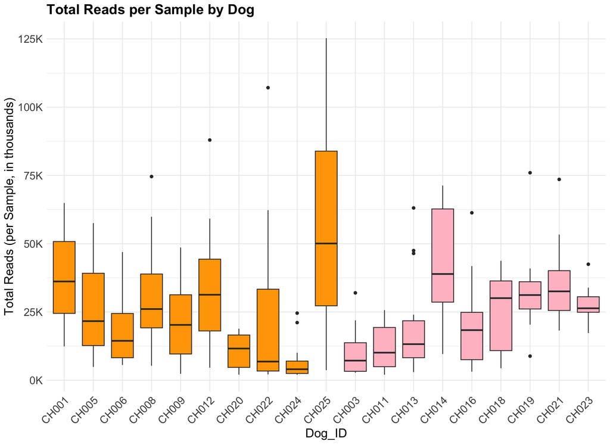

```r
# Boxplot for total reads by Individual (each point = one sample)
p_reads <- ggplot(paired_sample_data, aes(x = Individual, y = total_reads, fill = Surgery_Type)) +
  geom_boxplot()  +
  scale_fill_manual(values = c(
    "Abdomen" = "orange",
    "Stifle" = "pink"
  )) +
  scale_y_continuous(
    labels = function(x) paste0(x / 1000, "K"),
    name = "Total Reads (per Sample, in thousands)"
  ) +
  labs(
    title = "Total Reads per Sample by Dog",
    x = "Dog_ID"
  ) +
  theme_minimal()+
  theme(
    axis.text.x = element_text(angle = 45, hjust = 1, size = 14),
    axis.text.y = element_text(size = 14),
    axis.title.x = element_text(size = 16),
    axis.title.y = element_text(size = 16),
    plot.title = element_text(size = 18, face = "bold"),
    legend.position = "none"
  )

p_reads
```

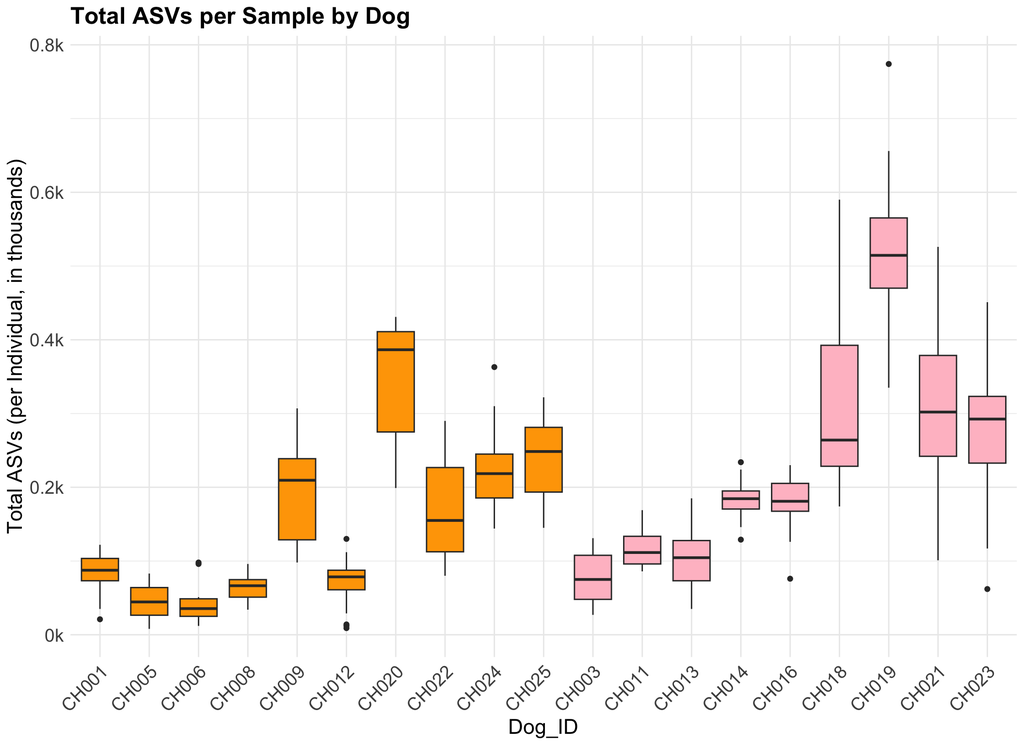

```r
out_reads <- paste0(out_dir, "/total_reads_by_individual_paired.png")
ggplot2::ggsave(out_reads, p_reads, width = 8, height = 6)


# Boxplot for total ASVs by Individual (each point = one sample)
p_asv <- ggplot(paired_sample_data, aes(x = Individual, y = total_asv, fill = Surgery_Type)) +
  geom_boxplot() +
  scale_fill_manual(values = c(
    "Abdomen" = "orange",
    "Stifle" = "pink"
  )) +
  scale_y_continuous(
    labels = function(x) paste0(x / 1000, "k"),
    name = "Total ASVs (per Individual, in thousands)"
  ) +
  labs(
    title = "Total ASVs per Sample by Dog",
    x = "Dog_ID"
  ) +
  theme_minimal()+
  theme(
    axis.text.x = element_text(angle = 45, hjust = 1, size = 14),
    axis.text.y = element_text(size = 14),
    axis.title.x = element_text(size = 16),
    axis.title.y = element_text(size = 16),
    plot.title = element_text(size = 18, face = "bold"),
    legend.position = "none"
  )
p_asv
```

```r
out_asv <- paste0(out_dir, "/total_asvs_by_individual_paired.png")
ggplot2::ggsave(out_asv, p_asv, width = 8, height = 6)
```

# Shannon Alpha-Diversity

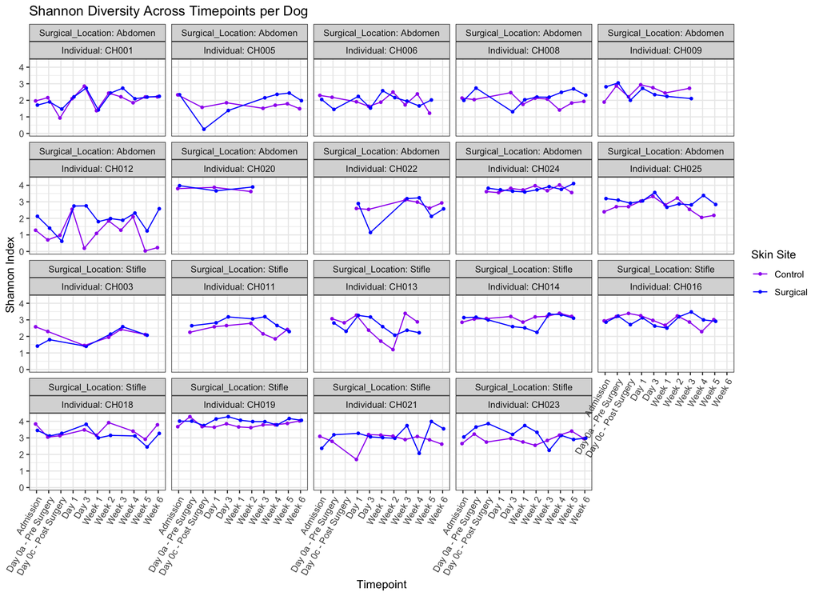

```r
alphadiv_plot_data <- estimate_richness(ps_2, measures = "Shannon") %>%
  rownames_to_column(var = "SampleID") %>%
  left_join(as.data.frame(sample_data(ps_2)), by = "SampleID") %>%
  group_by(Individual) %>%
  mutate(Surgical_Location = Sample_Location[Sample_Site == "Surgical"][1]) %>%
  ungroup() %>%
  mutate(Surgical_Location = factor(Surgical_Location)) %>%
  arrange(Surgical_Location, Individual)
ggplot(alphadiv_plot_data, aes(x = factor(Day_Order), y = Shannon, color = Sample_Site, group = Sample_Site)) +
  geom_point(size = 1, position = position_dodge(width = 0.3)) +
  geom_line(position = position_dodge(width = 0.3)) +
  facet_wrap(
    Surgical_Location ~ Individual,
    labeller = label_both
  ) +
  scale_color_manual(values = c("Control" = "purple", "Surgical" = "blue")) +
  theme_bw() +
  labs(
    title = "Shannon Diversity Across Timepoints per Dog",
    x = "Timepoint",
    y = "Shannon Index",
    color = "Skin Site"
  ) +
  theme(axis.text.x = element_text(angle = 60, hjust = 1))
```

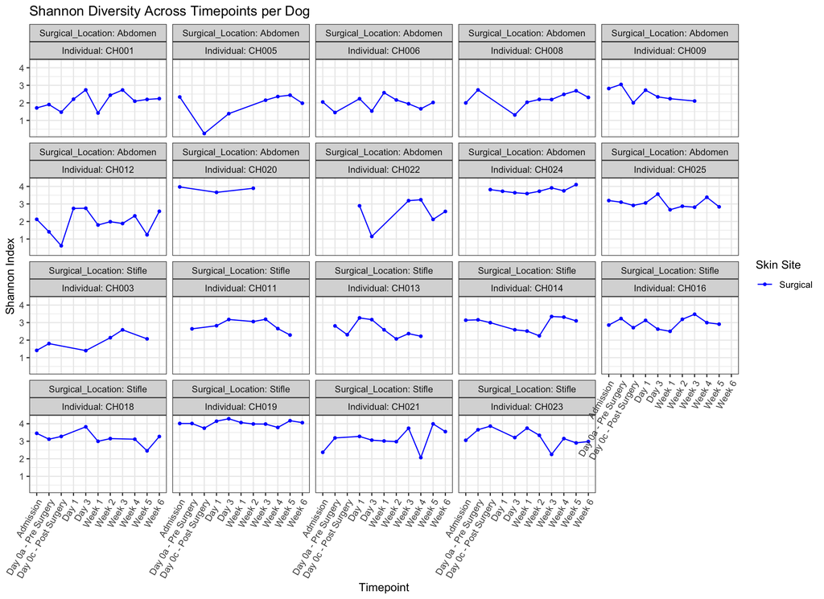

```r
alphadiv_plot_data_surg <- estimate_richness(ps_2, measures = "Shannon") %>%
  filter(sample_data(ps_2)$Sample_Site == "Surgical")  %>%
  rownames_to_column(var = "SampleID") %>%
  left_join(as.data.frame(sample_data(ps_2)), by = "SampleID") %>%
  group_by(Individual) %>%
  mutate(Surgical_Location = Sample_Location[Sample_Site == "Surgical"][1]) %>%
  ungroup() %>%
  mutate(Surgical_Location = factor(Surgical_Location)) %>%
  arrange(Surgical_Location, Individual)
ggplot(alphadiv_plot_data_surg, aes(x = factor(Day_Order), y = Shannon, color = Sample_Site, group = Sample_Site)) +
  geom_point(size = 1, position = position_dodge(width = 0.3)) +
  geom_line(position = position_dodge(width = 0.3)) +
  facet_wrap(
    Surgical_Location ~ Individual,
    labeller = label_both
  ) +
  scale_color_manual(values = c("Surgical" = "blue")) +
  theme_bw() +
  labs(
    title = "Shannon Diversity Across Timepoints per Dog",
    x = "Timepoint",
    y = "Shannon Index",
    color = "Skin Site"
  ) +
  theme(axis.text.x = element_text(angle = 60, hjust = 1))
```

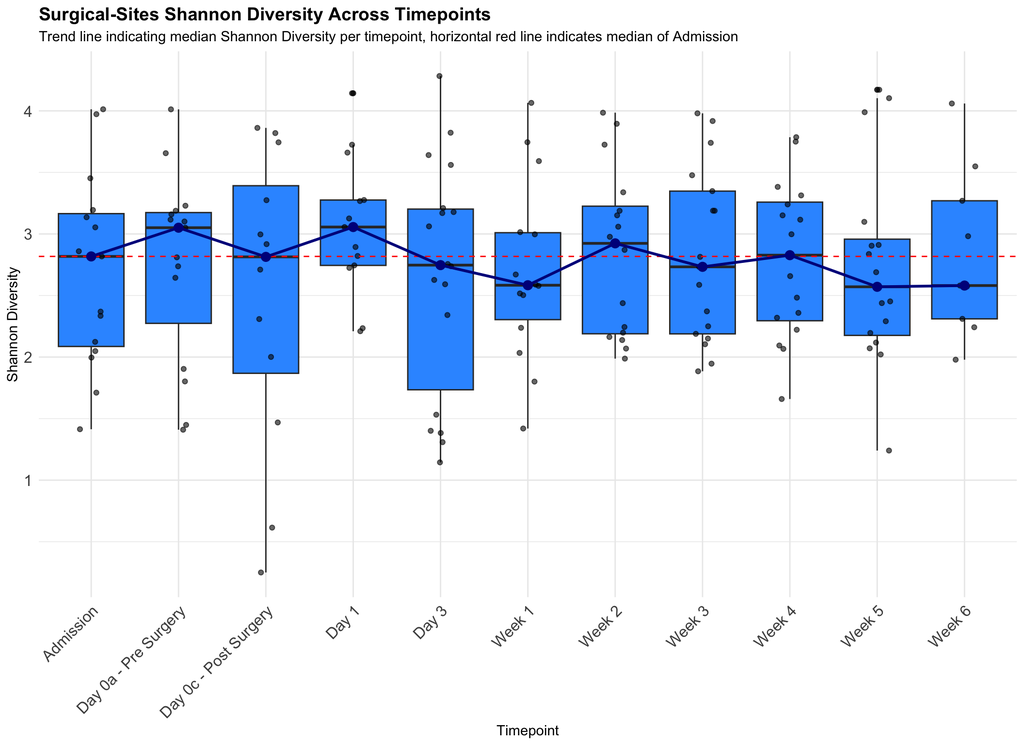

```r
alphadiv_plot_surgical <- estimate_richness(ps_2, measures = "Shannon") %>%
  rownames_to_column(var = "SampleID") %>%
  left_join(as.data.frame(sample_data(ps_2)), by = "SampleID") %>%
  filter(Sample_Site == "Surgical") %>%
  mutate(Sample_Location = factor(Sample_Location)) %>%
  arrange(Sample_Location, Individual)

alphadiv_plot_surgical_median <- alphadiv_plot_surgical %>%
  group_by(Day_Order) %>%
  summarise(median_Shannon = median(Shannon, na.rm = TRUE), .groups = "drop")


ggplot(alphadiv_plot_surgical, aes(x = Day_Order, y = Shannon)) +
  geom_boxplot(fill = "#3399FF") +
  geom_jitter(width = 0.15, alpha = 0.6, color = "black") +

  geom_hline(yintercept = alphadiv_plot_surgical_median$median_Shannon[1], linetype = "dashed", color="red") +
  geom_point(data = alphadiv_plot_surgical_median, aes(x = Day_Order, y = median_Shannon),
             inherit.aes = FALSE, color = "darkblue", size = 3) +
  geom_line(data = alphadiv_plot_surgical_median, aes(x = Day_Order, y = median_Shannon, group = 1),
            inherit.aes = FALSE, color = "darkblue", linewidth = 1) +
  labs(
    title = "Surgical-Sites Shannon Diversity Across Timepoints",
    subtitle = "Trend line indicating median Shannon Diversity per timepoint, horizontal red line indicates median of Admission",
    x = "Timepoint",
    y = "Shannon Diversity"
  ) +
  theme_minimal() +
  theme(
    plot.title = element_text(size = 14, face = "bold"),
    axis.text.x = element_text(size = 12, angle = 45, hjust = 1),
    axis.text.y = element_text(size = 12)
  )
```

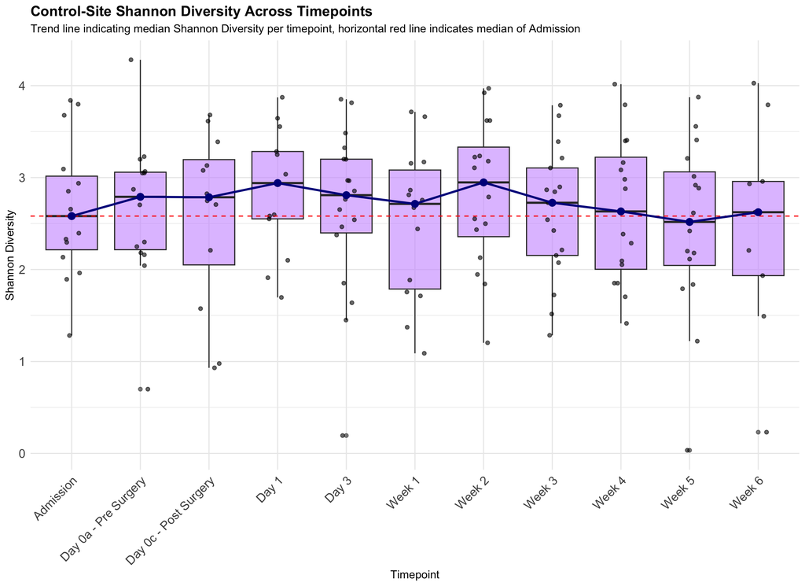

```r
alphadiv_plot_control <- estimate_richness(ps_2, measures = "Shannon") %>%
  rownames_to_column(var = "SampleID") %>%
  left_join(as.data.frame(sample_data(ps_2)), by = "SampleID") %>%
  filter(Sample_Site == "Control") %>%
  mutate(Sample_Location = factor(Sample_Location)) %>%
  arrange(Sample_Location, Individual)

alphadiv_plot_control_median <- alphadiv_plot_control %>%
  group_by(Day_Order) %>%
  summarise(median_Shannon = median(Shannon, na.rm = TRUE), .groups = "drop")


ggplot(alphadiv_plot_control, aes(x = Day_Order, y = Shannon)) +
  geom_boxplot(fill = "#CC99FF", alpha = 0.6) +
  geom_jitter(width = 0.15, alpha = 0.6, color = "black") +

  geom_hline(yintercept = alphadiv_plot_control_median$median_Shannon[1], linetype = "dashed", color="red") +
  geom_point(data = alphadiv_plot_control_median, aes(x = Day_Order, y = median_Shannon),
             inherit.aes = FALSE, color = "darkblue", size = 3) +
  geom_line(data = alphadiv_plot_control_median, aes(x = Day_Order, y = median_Shannon, group = 1),
            inherit.aes = FALSE, color = "darkblue", linewidth = 1) +
  labs(
    title = "Control-Site Shannon Diversity Across Timepoints",
    subtitle = "Trend line indicating median Shannon Diversity per timepoint, horizontal red line indicates median of Admission",
    x = "Timepoint",
    y = "Shannon Diversity"
  ) +
  theme_minimal() +
  theme(
    plot.title = element_text(size = 14, face = "bold"),
    axis.text.x = element_text(size = 12, angle = 45, hjust = 1),
    axis.text.y = element_text(size = 12)
  )
```

# Bray-Curtis (BC) Dissimilarity

```r
# Generate bray-curtis distance matrix using ASV relative abundances
bray_dist <- phyloseq::distance(ps_rel_2, method = "bray")
bray_matrix <- as.matrix(bray_dist)

sd <- as(sample_data(ps_rel_2), "data.frame")


sd <- sd %>%
  mutate(
    Time_Group = case_when(
      Day_Order %in% c("Admission", "Day 0a - Pre Surgery") ~ "Before_Surgery",
      Day_Order %in% c("Admission", "Day 0c - Post Surgery") ~ "Post_Surgery",
      Day_Order %in% c("Day 1", "Day 3")                   ~ "Inflammation",
      Day_Order %in% c("Week 1", "Week 2")                   ~ "Proliferation",
      Day_Order %in% c("Week 3", "Week 4", "Week 5", "Week 6")       ~ "Maturation",
      TRUE                                                 ~ "NA"
    )
  )


sd$Time_Group <- factor(sd$Time_Group, levels = c("Before_Surgery", "Post_Surgery", "Inflammation", "Proliferation", "Maturation"))

sample_data(ps_rel_2) <- sample_data(sd)
```

# Check: Skin Site Effect (Abdomen vs Stifle)

### PERMANOVA Test

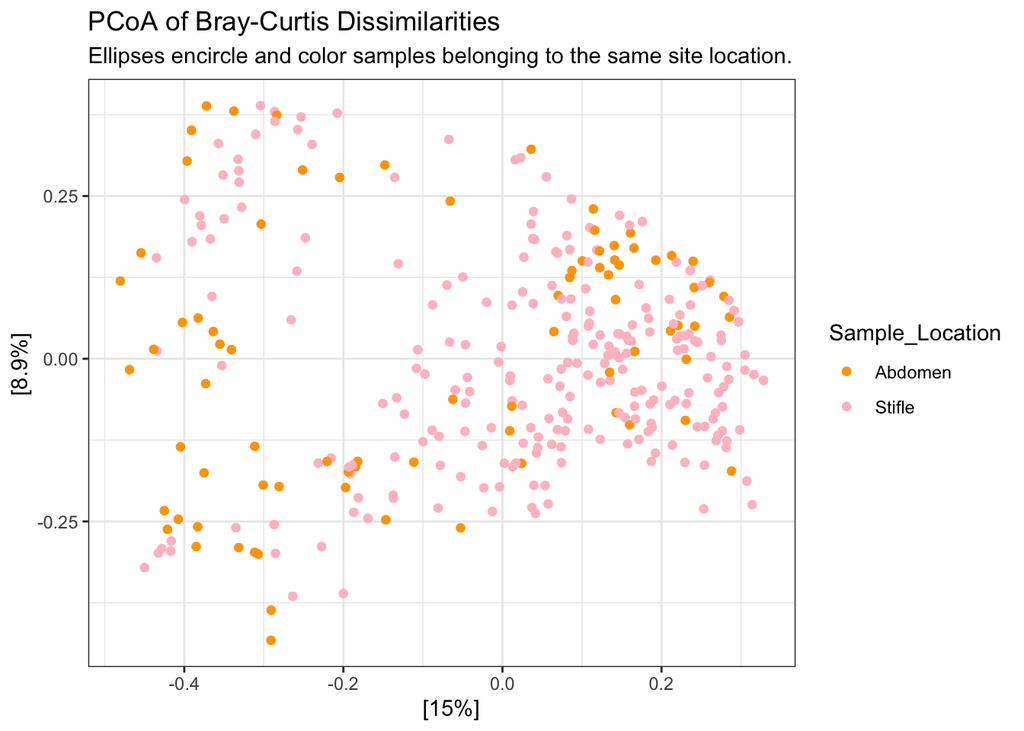

```r
# Across all days is there a difference between stifle and abdomen?
set.seed(100)
bray_pcoa <- ordinate(ps_rel_2, method = "PCoA", distance = as.dist(bray_dist))

p1 <- plot_ordination(ps_rel_2, bray_pcoa, color = "Sample_Location") +
  geom_point(size = 1.5) +
  scale_color_manual(values = c("Stifle" = "pink", "Abdomen" = "orange")) +
  theme_bw() +
  ggtitle(
    "PCoA of Bray-Curtis Dissimilarities",
    subtitle = "Ellipses encircle and color samples belonging to the same site location."
  )

p1
```

```r
# PERMANOVA test on
set.seed(100)
adonis2(bray_matrix ~ Sample_Location, data = paired_sample_data, permutations = 999, by = "margin")
```

|  | Df | SumOfSqs | R2 | F | Pr(>F) |
| --- | --- | --- | --- | --- | --- |
| Sample_Location | 1 | 2.226883 | 0.02145678 | 7.016727 | 0.001 |
| Residual | 320 | 101.557678 | 0.97854322 | NA | NA |
| Total | 321 | 103.784561 | 1.00000000 | NA | NA |

```r
# All days: Control vs Surgical differences in Abdomen Groups (aka stifle control vs abdomen sites)
metadata_abdomen <- paired_sample_data %>%
  filter(Surgery_Type == "Abdomen")
abdomen_bray_dist <- bray_matrix[metadata_abdomen$SampleID, metadata_abdomen$SampleID]
abdomen_bray_dist_obj <- as.dist(abdomen_bray_dist)

set.seed(100)
adonis2(abdomen_bray_dist_obj ~ Sample_Site, data = metadata_abdomen, permutations = 999, by = "margin")
```

|  | Df | SumOfSqs | R2 | F | Pr(>F) |
| --- | --- | --- | --- | --- | --- |
| Sample_Site | 1 | 0.3258838 | 0.006048425 | 0.973637 | 0.406 |
| Residual | 160 | 53.5532331 | 0.993951575 | NA | NA |
| Total | 161 | 53.8791169 | 1.000000000 | NA | NA |

```r
# All days: Control vs Surgical differences in Stifle Groups
metadata_stifle <- paired_sample_data %>%
  filter(Surgery_Type == "Stifle")
Stifle_bray_dist <- bray_matrix[metadata_stifle$SampleID, metadata_stifle$SampleID]
Stifle_bray_dist_obj <- as.dist(Stifle_bray_dist)

set.seed(100)
adonis2(Stifle_bray_dist_obj ~ Sample_Site, data = metadata_stifle, permutations = 999, by = "margin")
```

|  | Df | SumOfSqs | R2 | F | Pr(>F) |
| --- | --- | --- | --- | --- | --- |
| Sample_Site | 1 | 0.2659574 | 0.005856386 | 0.9307599 | 0.574 |
| Residual | 158 | 45.1472735 | 0.994143614 | NA | NA |
| Total | 159 | 45.4132309 | 1.000000000 | NA | NA |

```r
# Before Surgery?
paired_sample_data_before <- paired_sample_data %>%
  filter(Day_Order %in% c("Admission", "Day 0a - Pre-Surgery"))

# subset phyloseq object
ps_rel_2_before_surgery <- subset_samples(
  ps_rel_2,
  Day_Order %in% c("Admission", "Day 0a - Pre-Surgery")
)

# subset BC matrix
paired_sample_data_before <- paired_sample_data_before %>%
  filter(SampleID %in% rownames(bray_matrix)) %>%
  arrange(match(SampleID, rownames(bray_matrix)))

before_surgery_bray_dist <- bray_matrix[
  paired_sample_data_before$SampleID,
  paired_sample_data_before$SampleID
]


# PERMANOVA test on
set.seed(100)
adonis2(before_surgery_bray_dist ~ Sample_Location, data = paired_sample_data_before, permutations = 999, by = "margin")
```

|  | Df | SumOfSqs | R2 | F | Pr(>F) |
| --- | --- | --- | --- | --- | --- |
| Sample_Location | 1 | 0.3322457 | 0.03541925 | 1.028156 | 0.391 |
| Residual | 28 | 9.0481255 | 0.96458075 | NA | NA |
| Total | 29 | 9.3803713 | 1.00000000 | NA | NA |

```r
# Before surgery: Control vs Surgical differences in Abdomen Groups (aka stifle control vs abdomen sites)
metadata_abdomen <- paired_sample_data_before %>%
  filter(Surgery_Type == "Abdomen")
abdomen_bray_dist <- before_surgery_bray_dist[metadata_abdomen$SampleID, metadata_abdomen$SampleID]
abdomen_bray_dist_obj <- as.dist(abdomen_bray_dist)

set.seed(100)
adonis2(abdomen_bray_dist_obj ~ Sample_Site, data = metadata_abdomen, permutations = 999, by = "margin")
```

|  | Df | SumOfSqs | R2 | F | Pr(>F) |
| --- | --- | --- | --- | --- | --- |
| Sample_Site | 1 | 0.2515057 | 0.04976351 | 0.7331745 | 0.664 |
| Residual | 14 | 4.8025135 | 0.95023649 | NA | NA |
| Total | 15 | 5.0540193 | 1.00000000 | NA | NA |

```r
# Before surgery: Control vs Surgical differences in Stifle Groups
metadata_stifle <- paired_sample_data_before %>%
  filter(Surgery_Type == "Stifle")
Stifle_bray_dist <- before_surgery_bray_dist[metadata_stifle$SampleID, metadata_stifle$SampleID]
Stifle_bray_dist_obj <- as.dist(Stifle_bray_dist)

set.seed(100)
adonis2(Stifle_bray_dist_obj ~ Sample_Site, data = metadata_stifle, permutations = 999, by = "margin")
```

|  | Df | SumOfSqs | R2 | F | Pr(>F) |
| --- | --- | --- | --- | --- | --- |
| Sample_Site | 1 | 0.2103347 | 0.05672939 | 0.721694 | 0.942 |
| Residual | 12 | 3.4973500 | 0.94327061 | NA | NA |
| Total | 13 | 3.7076847 | 1.00000000 | NA | NA |

### LMM

```r
bray_matrix <- as.matrix(before_surgery_bray_dist)
# How does the surgical site (abdomen or stifle) influence the dissimilarity to control site (stifle for all) before disturbance (ie surgery)?
bray_arcsin_s <- asin(sqrt(bray_matrix))
paired_distances <- paired_sample_data_before %>%
 group_by(Dog_ID, Day_Order, Surgery_Type) %>%
  summarise(
    Control_Sample = SampleID[Sample_Site == "Control"][1],
    Surgical_Sample = SampleID[Sample_Site == "Surgical"][1],
    Bray_Distance = bray_arcsin_s[Control_Sample, Surgical_Sample],
    Sample_Plate = Sample_Plate[1],
    Day_Order = Day_Order[1],
    Collection_Day = Collection_Day[1],
   .groups = "drop"
  )

lmer_bray <- lm(
  Bray_Distance ~ Surgery_Type,
  data = paired_distances
)

anova(lmer_bray)
```

|  | Df | Sum Sq | Mean Sq | F value | Pr(>F) |
| --- | --- | --- | --- | --- | --- |
| Surgery_Type | 1 | 0.07843307 | 0.07843307 | 1.084942 | 0.316579 |
| Residuals | 13 | 0.93980102 | 0.07229239 | NA | NA |

```r
summary(lmer_bray)
```

```
##
## Call:
## lm(formula = Bray_Distance ~ Surgery_Type, data = paired_distances)
##
## Residuals:
##      Min       1Q   Median       3Q      Max
## -0.37626 -0.19452  0.03467  0.23008  0.35267
##
## Coefficients:
##                    Estimate Std. Error t value Pr(>|t|)
## (Intercept)         0.83166    0.09506   8.749 8.29e-07 ***
## Surgery_TypeStifle  0.14494    0.13915   1.042    0.317
## ---
## Signif. codes:  0 '***' 0.001 '**' 0.01 '*' 0.05 '.' 0.1 ' ' 1
##
## Residual standard error: 0.2689 on 13 degrees of freedom
## Multiple R-squared:  0.07703,    Adjusted R-squared:  0.006031
## F-statistic: 1.085 on 1 and 13 DF,  p-value: 0.3166
```

# Change-point analysis

## PERMANOVA

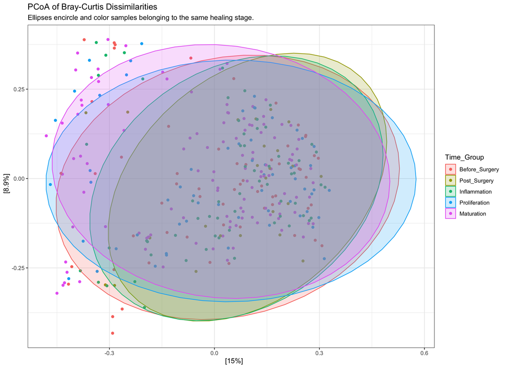

```r
# Generate bray-curtis distance matrix using ASV relative abundances
bray_dist <- phyloseq::distance(ps_rel_2, method = "bray")
bray_matrix <- as.matrix(bray_dist)

# ordinate PCoA from full bray-curtis matrix
set.seed(100)

bray_pcoa <- ordinate(ps_rel_2, method = "PCoA", distance =  bray_dist)

p1 <- plot_ordination(ps_rel_2, bray_pcoa, color = "Time_Group")


p1 + ggtitle("PCoA of Bray-Curtis Dissimilarities", subtitle = "Ellipses encircle and color samples belonging to the same healing stage.") +
  geom_point(size = 1.5) +
  theme_bw() +
  stat_ellipse(aes(fill = Time_Group, group = Time_Group), alpha = 0.2, geom = "polygon")
```

```r
scores <- bray_pcoa$vectors
pc1 <- scores[, 1]

pc1_df <- as.data.frame(pc1) %>%
  rownames_to_column("SampleID")

paired_sample_data_pc1 <- left_join(paired_sample_data, pc1_df, by = "SampleID")

# extract PCoA coordinates (axis 1) from control and surgical samples
metadata_ctrl <- paired_sample_data_pc1 %>%
  filter(Sample_Site == "Control")
metadata_ctrl_median <- metadata_ctrl %>%
  group_by(Day_Order) %>%
  summarise(median_PCOA = median(pc1, na.rm = TRUE), .groups = "drop")

metadata_surg <- paired_sample_data_pc1 %>%
  filter(Sample_Site == "Surgical")
metadata_surg_median <- metadata_surg %>%
  group_by(Day_Order) %>%
  summarise(median_PCOA = median(pc1, na.rm = TRUE), .groups = "drop")



# Run PERMANOVA on control-subset bray curtis matrix
set.seed(100)
ctrl_bray_dist <- bray_matrix[metadata_ctrl$SampleID, metadata_ctrl$SampleID]
ctrl_bray_dist_obj <- as.dist(ctrl_bray_dist)
ps_rel_2_ctrl <- ps_rel_2 %>% subset_samples(Sample_Site == "Control")

ctrl_permanova <- adonis2(
  ctrl_bray_dist_obj ~ Day_Order,
  data = metadata_ctrl,
  strata = metadata_ctrl$Dog_ID,
  permutations = 999
)

print(ctrl_permanova)
```

```
## Permutation test for adonis under reduced model
## Blocks:  strata
## Permutation: free
## Number of permutations: 999
##
## adonis2(formula = ctrl_bray_dist_obj ~ Day_Order, data = metadata_ctrl, permutations = 999, strata = metadata_ctrl$Dog_ID)
##           Df SumOfSqs      R2      F Pr(>F)
## Model     10    2.697 0.05122 0.8097  0.201
## Residual 150   49.955 0.94878
## Total    160   52.651 1.00000
```

```r
# Run pairwise - PERMANOVA on control-subset bray curtis matrix
set.seed(100)
pairwise_results_ctrl <- pairwise.adonis2(
  ctrl_bray_dist_obj ~ Day_Order,
  strata = "Dog_ID",
  data = metadata_ctrl,
  nperm = 999)

p_values <- sapply(names(pairwise_results_ctrl)[-1], function(x) {
  pairwise_results_ctrl[[x]][["Pr(>F)"]][1]
})

# Benjamini-Hochberg (BH) adjustment since we are testing multiple comparisons
p_adjusted <- p.adjust(p_values, method = "BH")

pairwise_df <- data.frame(
  Comparison = names(p_values),
  p_value    = p_values,
  p_adj      = p_adjusted,
  row.names  = NULL
)

groups <- str_split_fixed(pairwise_df$Comparison, "_vs_", 2)

pairwise_df$Group1 <- groups[, 1]
pairwise_df$Group2 <- groups[, 2]

pairwise_df <- pairwise_df[, c("Group1", "Group2", "p_value", "p_adj")]

alpha <- 0.05
pairwise_tidy_ctrl <- pairwise_df %>%
  filter(!is.na(p_adj)) %>%
  mutate(
    Significant = ifelse(p_adj <= alpha, "Yes", "No"),
    Stars = case_when(
      p_adj <= 0.001 ~ "***",
      p_adj <= 0.01  ~ "**",
      p_adj <= 0.05  ~ "*",
      p_adj <= 0.10 ~ ".",
      TRUE ~ ""
    ),
    p_adj = round(p_adj, 4) ) %>%
  arrange(p_adj)



# Filter out insignificant pairwise results

 sig_df_ctrl <- pairwise_tidy_ctrl %>%
  filter(Significant == "Yes") %>%
  mutate(
    group1 = Group1,
    group2 = Group2,
    y.position = NA_real_,
    label = Stars
  )
x_levels <- levels(factor(metadata_ctrl$Day_Order))

sig_df_ctrl <- sig_df_ctrl %>%
  mutate(
    xmin = match(group1, x_levels),
    xmax = match(group2, x_levels)
  ) %>%
  arrange(p_value) %>%
  mutate(
    y.position = max(metadata_ctrl$pc1, na.rm = TRUE) +
      seq(0.05, by = 0.05, length.out = n())
  )
print(sig_df_ctrl)
```

```
##  [1] Group1      Group2      p_value     p_adj       Significant Stars
##  [7] group1      group2      y.position  label       xmin        xmax
## <0 rows> (or 0-length row.names)
```

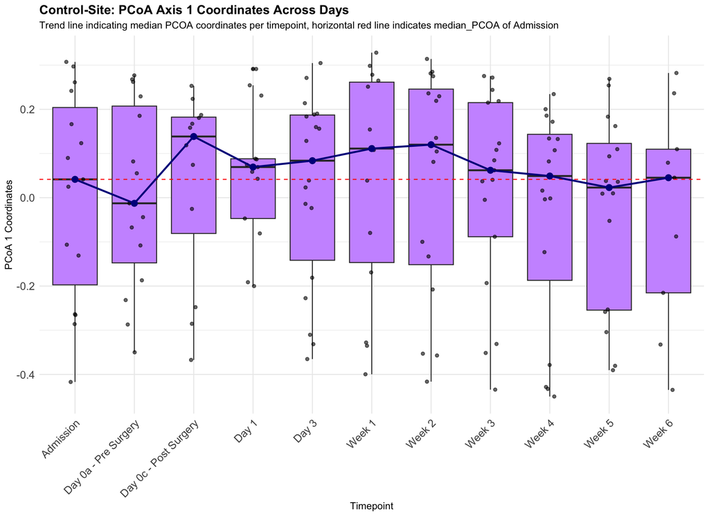

```r
ggplot(metadata_ctrl, aes(x = Day_Order, y = pc1)) +
  geom_boxplot(fill = "#CC99FF") +
  geom_jitter(width = 0.15, alpha = 0.6, color = "black") +

  geom_hline(yintercept = metadata_ctrl_median$median_PCOA[1], linetype = "dashed", color="red") +
  geom_point(data = metadata_ctrl_median, aes(x = Day_Order, y = median_PCOA),
             inherit.aes = FALSE, color = "darkblue", size = 3) +
  geom_line(data = metadata_ctrl_median, aes(x = Day_Order, y = median_PCOA, group = 1),
            inherit.aes = FALSE, color = "darkblue", linewidth = 1) +

  labs(
    title = "Control-Site: PCoA Axis 1 Coordinates Across Days",
    subtitle = "Trend line indicating median PCOA coordinates per timepoint, horizontal red line indicates median_PCOA of Admission",
    x = "Timepoint",
    y = "PCoA 1 Coordinates"
  ) +
  theme_minimal() +
  theme(
    plot.title = element_text(size = 14, face = "bold"),
    axis.text.x = element_text(size = 12, angle = 45, hjust = 1),
    axis.text.y = element_text(size = 12)
  )
```

```r
# Surgical groups
set.seed(100)

surg_bray_dist <- bray_matrix[metadata_surg$SampleID, metadata_surg$SampleID]
surg_bray_dist_obj <- as.dist(surg_bray_dist)
ps_rel_2_surg <- ps_rel_2 %>% subset_samples(Sample_Site == "Surgical")

surg_permanova <- adonis2(
  surg_bray_dist_obj ~ Day_Order,
  data = metadata_surg,
  strata = metadata_surg$Dog_ID,
  permutations = 999
)

print(surg_permanova)
```

```
## Permutation test for adonis under reduced model
## Blocks:  strata
## Permutation: free
## Number of permutations: 999
##
## adonis2(formula = surg_bray_dist_obj ~ Day_Order, data = metadata_surg, permutations = 999, strata = metadata_surg$Dog_ID)
##           Df SumOfSqs      R2     F Pr(>F)
## Model     10    2.629 0.05171 0.818  0.294
## Residual 150   48.205 0.94829
## Total    160   50.834 1.00000
```

```r
### Pairwise PERMANOVA
set.seed(100)
pairwise_results_surg <- pairwise.adonis2(
  surg_bray_dist_obj ~ Day_Order,
  strata = "Dog_ID",
  data = metadata_surg,
  nperm = 999)

p_values <- sapply(names(pairwise_results_surg)[-1], function(x) {
  pairwise_results_surg[[x]][["Pr(>F)"]][1]
})

# Benjamini-Hochberg (BH) adjustment since we are testing multiple comparisons
p_adjusted <- p.adjust(p_values, method = "BH")

pairwise_df <- data.frame(
  Comparison = names(p_values),
  p_value    = p_values,
  p_adj      = p_adjusted,
  row.names  = NULL
)

groups <- str_split_fixed(pairwise_df$Comparison, "_vs_", 2)

pairwise_df$Group1 <- groups[, 1]
pairwise_df$Group2 <- groups[, 2]

pairwise_df <- pairwise_df[, c("Group1", "Group2", "p_value", "p_adj")]

alpha <- 0.05
pairwise_tidy_surg <- pairwise_df %>%
  filter(!is.na(p_adj)) %>%
  mutate(
    Significant = ifelse(p_adj <= alpha, "Yes", "No"),
    Stars = case_when(
      p_adj <= 0.001 ~ "***",
      p_adj <= 0.01  ~ "**",
      p_adj <= 0.05  ~ "*",
      p_adj <= 0.10 ~ ".",
      TRUE ~ ""
    ),
    p_adj = round(p_adj, 4) ) %>%
  arrange(p_adj)





 sig_df_surg <- pairwise_tidy_surg %>%
  filter(Significant == "Yes") %>%
  mutate(
    group1 = Group1,
    group2 = Group2,
    y.position = NA_real_,
    label = Stars
  )
x_levels <- levels(factor(metadata_surg$Day_Order))

sig_df_surg <- sig_df_surg %>%
  mutate(
    xmin = match(group1, x_levels),
    xmax = match(group2, x_levels)
  ) %>%
  arrange(p_value) %>%
  mutate(
    y.position = max(metadata_surg$pc1, na.rm = TRUE) +
      seq(0.05, by = 0.05, length.out = n())
  )
print(sig_df_surg)
```

```
##  [1] Group1      Group2      p_value     p_adj       Significant Stars
##  [7] group1      group2      y.position  label       xmin        xmax
## <0 rows> (or 0-length row.names)
```

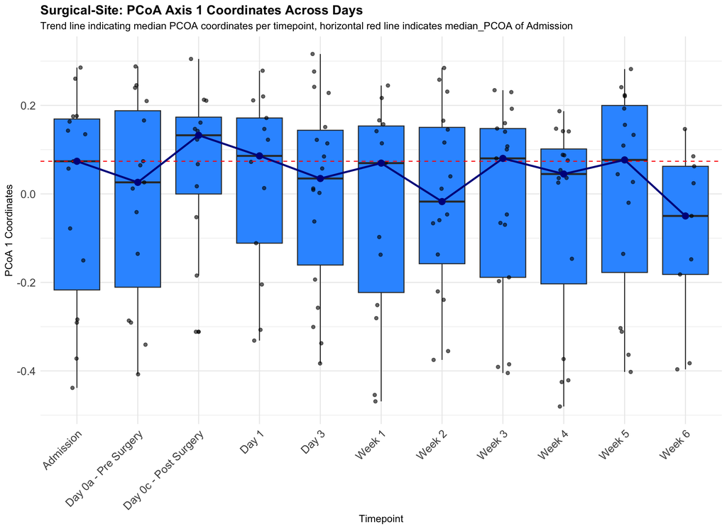

```r
ggplot(metadata_surg, aes(x = Day_Order, y = pc1)) +
  geom_boxplot(fill = "#3399FF") +
  geom_jitter(width = 0.15, alpha = 0.6, color = "black") +

  geom_hline(yintercept = metadata_surg_median$median_PCOA[1], linetype = "dashed", color="red") +
  geom_point(data = metadata_surg_median, aes(x = Day_Order, y = median_PCOA),
             inherit.aes = FALSE, color = "darkblue", size = 3) +
  geom_line(data = metadata_surg_median, aes(x = Day_Order, y = median_PCOA, group = 1),
            inherit.aes = FALSE, color = "darkblue", linewidth = 1) +

  labs(
    title = "Surgical-Site: PCoA Axis 1 Coordinates Across Days",
    subtitle = "Trend line indicating median PCOA coordinates per timepoint, horizontal red line indicates median_PCOA of Admission",
    x = "Timepoint",
    y = "PCoA 1 Coordinates"
  ) +
  theme_minimal() +

  theme(
    plot.title = element_text(size = 14, face = "bold"),
    axis.text.x = element_text(size = 12, angle = 45, hjust = 1),
    axis.text.y = element_text(size = 12)
  )
```